# House Prices Prediction Project

## House Price Prediction Project

### Danxuan Han

This project is stemed from one of the Kaggle's competitions- [House Prices: Advanced Regression Techniques](https://www.kaggle.com/c/house-prices-advanced-regression-techniques).  
To dig into the problem, I studied some notes from kaggle's kernel, inspired by their methods, I generated my own research report.

**References:**  
1.[Comprehensive data exploration with Python](https://www.kaggle.com/pmarcelino/comprehensive-data-exploration-with-python)--provides elegant Python code to visualize data  
2.[A study on Regression applied to the Ames dataset](https://www.kaggle.com/juliencs/a-study-on-regression-applied-to-the-ames-dataset)--provides some ideas of feature constructing, and dealing with missing value  
3.[XGBoost + Lasso](https://www.kaggle.com/humananalog/xgboost-lasso)--provides good idea to process feature's data  
4.[Stacked Regression: Top 4% on LeaderBoard](https://www.kaggle.com/serigne/stacked-regressions-top-4-on-leaderboard)--good and comprehensive example for data processing, feature engineering  
5.[Handling missing values](https://www.kaggle.com/dansbecker/handling-missing-values)--talking about advantages and shortcomings of some different ways to deal with missing values, although not comprehensive enough

```python
import pandas as pd
import numpy as np
```

```python
from scipy import stats
%matplotlib inline
import matplotlib.pyplot as plt
import seaborn as sns
color = sns.color_palette()
sns.set_style('darkgrid')
```

### 1. Data Processing

**General look at the data:**

```python
df_train = pd.read_csv('train.csv')
```

```python
df_train.head()
```

|  | Id | MSSubClass | MSZoning | LotFrontage | LotArea | Street | Alley | LotShape | LandContour | Utilities | ... | PoolArea | PoolQC | Fence | MiscFeature | MiscVal | MoSold | YrSold | SaleType | SaleCondition | SalePrice |
| --- | --- | --- | --- | --- | --- | --- | --- | --- | --- | --- | --- | --- | --- | --- | --- | --- | --- | --- | --- | --- | --- |
| 0 | 1 | 60 | RL | 65.0 | 8450 | Pave | NaN | Reg | Lvl | AllPub | ... | 0 | NaN | NaN | NaN | 0 | 2 | 2008 | WD | Normal | 208500 |
| 1 | 2 | 20 | RL | 80.0 | 9600 | Pave | NaN | Reg | Lvl | AllPub | ... | 0 | NaN | NaN | NaN | 0 | 5 | 2007 | WD | Normal | 181500 |
| 2 | 3 | 60 | RL | 68.0 | 11250 | Pave | NaN | IR1 | Lvl | AllPub | ... | 0 | NaN | NaN | NaN | 0 | 9 | 2008 | WD | Normal | 223500 |
| 3 | 4 | 70 | RL | 60.0 | 9550 | Pave | NaN | IR1 | Lvl | AllPub | ... | 0 | NaN | NaN | NaN | 0 | 2 | 2006 | WD | Abnorml | 140000 |
| 4 | 5 | 60 | RL | 84.0 | 14260 | Pave | NaN | IR1 | Lvl | AllPub | ... | 0 | NaN | NaN | NaN | 0 | 12 | 2008 | WD | Normal | 250000 |

5 rows × 81 columns

```python
df_train.shape
```

```
(1460, 81)
```

**Our aim- the response variable is the last column: SalePrice**

```python
df_train['SalePrice'].describe()
```

```
count      1460.000000
mean     180921.195890
std       79442.502883
min       34900.000000
25%      129975.000000
50%      163000.000000
75%      214000.000000
max      755000.000000
Name: SalePrice, dtype: float64
```

**The dataset provides features including:**

```python
df_train.columns
```

```
Index(['Id', 'MSSubClass', 'MSZoning', 'LotFrontage', 'LotArea', 'Street',
       'Alley', 'LotShape', 'LandContour', 'Utilities', 'LotConfig',
       'LandSlope', 'Neighborhood', 'Condition1', 'Condition2', 'BldgType',
       'HouseStyle', 'OverallQual', 'OverallCond', 'YearBuilt', 'YearRemodAdd',
       'RoofStyle', 'RoofMatl', 'Exterior1st', 'Exterior2nd', 'MasVnrType',
       'MasVnrArea', 'ExterQual', 'ExterCond', 'Foundation', 'BsmtQual',
       'BsmtCond', 'BsmtExposure', 'BsmtFinType1', 'BsmtFinSF1',
       'BsmtFinType2', 'BsmtFinSF2', 'BsmtUnfSF', 'TotalBsmtSF', 'Heating',
       'HeatingQC', 'CentralAir', 'Electrical', '1stFlrSF', '2ndFlrSF',
       'LowQualFinSF', 'GrLivArea', 'BsmtFullBath', 'BsmtHalfBath', 'FullBath',
       'HalfBath', 'BedroomAbvGr', 'KitchenAbvGr', 'KitchenQual',
       'TotRmsAbvGrd', 'Functional', 'Fireplaces', 'FireplaceQu', 'GarageType',
       'GarageYrBlt', 'GarageFinish', 'GarageCars', 'GarageArea', 'GarageQual',
       'GarageCond', 'PavedDrive', 'WoodDeckSF', 'OpenPorchSF',
       'EnclosedPorch', '3SsnPorch', 'ScreenPorch', 'PoolArea', 'PoolQC',
       'Fence', 'MiscFeature', 'MiscVal', 'MoSold', 'YrSold', 'SaleType',
       'SaleCondition', 'SalePrice'],
      dtype='object')
```

### Deal with missing values

**According to the given explaination of features [data_description.txt](https://drive.google.com/drive/u/1/folders/1TOUInZXfgOao1B6r82gmPyUGoCNysvz7), we could decide whether to fill with missing values in some features with 0 or with "None" or do the imputation to missing values**

```python
# find features with missing values, since from "Utilities", there is no missing data for other features, so
# I just show the top 20 features with missing data
df_train.isnull().sum().sort_values(ascending=False).head(20)
```

```
PoolQC          1453
MiscFeature     1406
Alley           1369
Fence           1179
FireplaceQu      690
LotFrontage      259
GarageCond        81
GarageType        81
GarageYrBlt       81
GarageFinish      81
GarageQual        81
BsmtExposure      38
BsmtFinType2      38
BsmtFinType1      37
BsmtCond          37
BsmtQual          37
MasVnrArea         8
MasVnrType         8
Electrical         1
Utilities          0
dtype: int64
```

(1) PoolQC: means pool quality  
from the description in the link of txt file above, we could tell that, NAN means the house don't have pool actually, our number of total observations is 1460, PoolQC has 99% missing values, may delete this features, but instead, I think having pool or not may make huge impact on sale prices, so I decide to fill NAN with "No" and maybe later I could set dummy variables to this feature

```python
df_train.loc[:, "PoolQC"] = df_train.loc[:, "PoolQC"].fillna("No")
```

**(2) MiscFeature: means miscellaneous feature not covered in other categories**  
Elev Elevator  
Gar2 2nd Garage (if not described in garage section)  
Othr Other  
Shed Shed (over 100 SF)  
TenC Tennis Court  
NA None  
**same as PoolQC, those miscellaneous features may make difference to the house price, may contribute to outliers, let's find out what those miscellaneous features are:**

```python
df_train[[df_train["MiscFeature"].iloc[i]=="Elev" for i in range(len(df_train))]]
# so, no oberservations has elevator
```

|  | Id | MSSubClass | MSZoning | LotFrontage | LotArea | Street | Alley | LotShape | LandContour | Utilities | ... | PoolArea | PoolQC | Fence | MiscFeature | MiscVal | MoSold | YrSold | SaleType | SaleCondition | SalePrice |
| --- | --- | --- | --- | --- | --- | --- | --- | --- | --- | --- | --- | --- | --- | --- | --- | --- | --- | --- | --- | --- | --- |

0 rows × 81 columns

```python
df_train[[df_train["MiscFeature"].iloc[i]=="Gar2" for i in range(len(df_train))]]
# 2 observations has 2nd garage
```

|  | Id | MSSubClass | MSZoning | LotFrontage | LotArea | Street | Alley | LotShape | LandContour | Utilities | ... | PoolArea | PoolQC | Fence | MiscFeature | MiscVal | MoSold | YrSold | SaleType | SaleCondition | SalePrice |
| --- | --- | --- | --- | --- | --- | --- | --- | --- | --- | --- | --- | --- | --- | --- | --- | --- | --- | --- | --- | --- | --- |
| 346 | 347 | 20 | RL | NaN | 12772 | Pave | NaN | IR1 | Lvl | AllPub | ... | 0 | No | NaN | Gar2 | 15500 | 4 | 2007 | WD | Normal | 151500 |
| 1230 | 1231 | 90 | RL | NaN | 18890 | Pave | NaN | IR1 | Lvl | AllPub | ... | 0 | No | NaN | Gar2 | 8300 | 8 | 2007 | WD | Normal | 190000 |

2 rows × 81 columns

```python
df_train[[df_train["MiscFeature"].iloc[i]=="Othr" for i in range(len(df_train))]]
# 2 other miscellaneous features
```

|  | Id | MSSubClass | MSZoning | LotFrontage | LotArea | Street | Alley | LotShape | LandContour | Utilities | ... | PoolArea | PoolQC | Fence | MiscFeature | MiscVal | MoSold | YrSold | SaleType | SaleCondition | SalePrice |
| --- | --- | --- | --- | --- | --- | --- | --- | --- | --- | --- | --- | --- | --- | --- | --- | --- | --- | --- | --- | --- | --- |
| 705 | 706 | 190 | RM | 70.0 | 5600 | Pave | NaN | Reg | Lvl | AllPub | ... | 0 | No | NaN | Othr | 3500 | 7 | 2010 | WD | Normal | 55000 |
| 873 | 874 | 40 | RL | 60.0 | 12144 | Pave | NaN | Reg | Lvl | AllPub | ... | 0 | No | NaN | Othr | 0 | 9 | 2009 | WD | Normal | 133000 |

2 rows × 81 columns

```python
shed_houses = df_train[[df_train["MiscFeature"].iloc[i]=="Shed" for i in range(len(df_train))]]
print(str(len(shed_houses))+" houses have sheds")
```

```
49 houses have sheds
```

```python
df_train[[df_train["MiscFeature"].iloc[i]=="TenC" for i in range(len(df_train))]]
# 1 house with Tennis court
```

|  | Id | MSSubClass | MSZoning | LotFrontage | LotArea | Street | Alley | LotShape | LandContour | Utilities | ... | PoolArea | PoolQC | Fence | MiscFeature | MiscVal | MoSold | YrSold | SaleType | SaleCondition | SalePrice |
| --- | --- | --- | --- | --- | --- | --- | --- | --- | --- | --- | --- | --- | --- | --- | --- | --- | --- | --- | --- | --- | --- |
| 1386 | 1387 | 60 | RL | 80.0 | 16692 | Pave | NaN | IR1 | Lvl | AllPub | ... | 519 | Fa | MnPrv | TenC | 2000 | 7 | 2006 | WD | Normal | 250000 |

1 rows × 81 columns

**Since I have figured out all data's meaning in the feature of "MiscFeature", I decide to set all other data of NAN value to "No", and those not-null value may be used as dummy variable later, or be ignored in the feature constructing process**

```python
df_train.loc[:, "MiscFeature"] = df_train.loc[:, "MiscFeature"].fillna("No")
```

**(3) Alley: Type of alley access to property**  
Grvl Gravel  
Pave Paved  
NA No alley access  
**so, same as PoolQC, we set NAN to "No"**  
**I have checked all other features, if NAN means doesn't have that feature, I will set those nan values to "No" in one step**

```python
df_train.loc[:, "Alley"] = df_train.loc[:, "Alley"].fillna("No")
df_train.loc[:, "Fence"] = df_train.loc[:, "Fence"].fillna("No")
df_train.loc[:, "FireplaceQu"] = df_train.loc[:, "FireplaceQu"].fillna("No")
df_train.loc[:, "GarageCond"] = df_train.loc[:, "GarageCond"].fillna("No")
df_train.loc[:, "GarageType"] = df_train.loc[:, "GarageType"].fillna("No")
df_train.loc[:, "GarageYrBlt"] = df_train.loc[:, "GarageYrBlt"].fillna("No")
df_train.loc[:, "GarageQual"] = df_train.loc[:, "GarageQual"].fillna("No")
```

**For the feature of BsmtExposure, it already includes "No" means no explosure, and nan means no basement,**

```python
df_train.loc[:, "BsmtExposure"] = df_train.loc[:, "BsmtExposure"].fillna("No basement")
df_train.loc[:, "BsmtFinType2"] = df_train.loc[:, "BsmtFinType2"].fillna("No basement type 2")
df_train.loc[:, "BsmtFinType1"] = df_train.loc[:, "BsmtFinType1"].fillna("No basement")
df_train.loc[:, "BsmtCond"] = df_train.loc[:, "BsmtCond"].fillna("No")
df_train.loc[:, "BsmtQual"] = df_train.loc[:, "BsmtQual"].fillna("No") #Evaluates the height of the basement
df_train.loc[:, "MasVnrType"] = df_train.loc[:, "MasVnrType"].fillna("None") # None is according to value of
# the original data
```

**(4) LotFrontage means Linear feet of street connected to property, so, if nan, means it maybe doesn't have property, since there is no house whose LotFrontage is 0 (have checked), so I would like to set those nan value to zero. Now, I am going to find other variables whose nan could changed to be zero**

```python
df_train.loc[:, "LotFrontage"] = df_train.loc[:, "LotFrontage"].fillna(0)
df_train.loc[:, "MasVnrArea"] = df_train.loc[:, "MasVnrArea"].fillna(0)
df_train.loc[:, "GarageFinish"] = df_train.loc[:, "GarageFinish"].fillna(0)
```

**(5) Feature "Electrical" only has one missing value, we could decide whether to put "Electrical" into our model first, if ""Electrical" is finally put into the model, we could delete that one oberservation with nan.**

### Converting the string values features into numerical features

First, converting the intensy leveled categorical features into numerical features.  
By stating "intensy leveled " I mean that those features could be quantified, for example, for the feature of "Alley", I could set gravel to 1, pave to 2 and no alley for 0, it means that pave alley will be 2 times than gravel. But for the feature of MSZoning, it has different values of "A", "C", "FV" etc, representing different zonging classification, so I couldn't set them from 1 to 3, because "C" shouldn't represent 2 times of A. So, in the first place, I just want to convert some categorical features which could be quantified directly. For other categorical features, I could add more features of dummy variables or just ignore them, this will be dealed later.

```python
df_train = df_train.replace(
                           {"Street": {"Grvl":1, "Pave": 2},
                            "Alley": {"Grvl":1, "Pave":2, "No": 0}, # replace no with 0
                            "LotShape": {"Regular": 4, "IR1":3, "IR2": 2, "IR3": 1},
                            "Utilities": {"AllPub": 4, "NoSewr": 3, "NoSeWa":2, "ELO":1},
                            "LandSlope": {"Gtl":1, "Mod":2, "Sev":3},
                            "ExterQual": {"Ex":5, "Gd":4, "TA":3, "Fa":2, "Po":1},
                            "ExterCond": {"Ex":5, "Gd":4, "TA":3, "Fa":2, "Po":1},
                            "BsmtQual": {"Ex":5, "Gd":4, "TA":3, "Fa":2, "Po":1, "No":0},
                            "BsmtCond": {"Ex":5, "Gd":4, "TA":3, "Fa":2, "Po":1, "No":0},
                            "BsmtExposure": {"Gd":4, "Av":3, "Mn":2, "No":1, "No basement": 0},
                            "BsmtFinType1": {"GLQ":3, "ALQ":3, "BLQ":2, "Rec":2, "LwQ": 1, "Unf":1, \
                                             "No basement": 0}, #simplify the category in the same time
                            "BsmtFinType2": {"GLQ":3, "ALQ":3, "BLQ":2, "Rec":2, "LwQ": 1, "Unf":1, \
                                             "No basement type 2": 0},
                            "HeatingQC": {"Ex":5, "Gd":4, "TA":3, "Fa":2, "Po":1},
                            "KitchenQual": {"Ex":5, "Gd":4, "TA":3, "Fa":2, "Po":1},
                            "FireplaceQu": {"Ex":5, "Gd":4, "TA":3, "Fa":2, "Po":1},
                            "GarageFinish": {"Fin": 3, "RFn": 2, "Unf": 1},
                            "GarageQual": {"Ex":5, "Gd":4, "TA":3, "Fa":2, "Po":1},
                            "GarageCond": {"Ex":5, "Gd":4, "TA":3, "Fa":2, "Po":1},
                            "PavedDrive": {"Y": 2, "P": 1, "N": 0},
                            "PoolQC": {"Ex":4, "Gd":3, "TA":2, "Fa":1, "No":0},
                            "Fence": {"GdPrv":1, "MnPrv":1, "GdWo":1, "MnWw":1, "No":0}})# see explaination below
```

**Some explainations about the feature process:**

1.Utilities: AllPub means have all public utilities, including electricity, water, gas, sewer, and other values mean lacking utilities, so the descending sort of 4, 3, 2, 1 may could better explain the completeness of utility and help to explain the house price. Same as LotShape.  
2.Fence: means fence quality, but the explaination in the txt file actually combined two categories into one, it includes the information of both privacy and the fence material, so, I decided to let it become a dummy variable, have fence: 1, no fence: 0.  
3.MiscVal, MiscFeature: MiscVal means value of miscellaneous feature, MiscFeature means if the house has elevator, shed or other miscellaneous feature, so I could just use MiscVal and delete feature of MiscFeature

```python
# drop some features mentioned above to be deleted
df_train.drop(['MiscFeature'], axis=1, inplace=True)
```

### Process numerical data

**First, we should figure out some seemingly numerical data are actually categorical data. For instance, MoSold, which means Month Sold (MM), the feature's values arange from 1 to 12, but 12 actually doesn't mean 12 times of 1, so we should be aware of those seemingly numerical features first.**

```python
# 1.YearBuilt, YearRemodAdd, MoSold, YrSold:
# For MoSold, maybe Months with the largest number of deals are significant, or maybe it is better to delete
# this feature.
# Construct a new feature of age of house, use YrSold-YearBuilt, and delete YearBuilt, since we want to remain the
# influence of market price inflation, so I think YrSold is still useful
df_train["HouseAge"] = df_train["YrSold"] - df_train["YearBuilt"]
df_train.drop(["YearBuilt","YearRemodAdd","MoSold"], axis=1, inplace=True)

# 2.BsmtUnfSF, BsmtFinSF1, BsmtFinSF2: BsmtUnfSF means unfinished area of basement, BsmtFinSF1 means finished area,
# they contain the same information, so we could delete the feature of BsmtUnfSF
df_train.drop(["BsmtUnfSF"], axis=1, inplace=True)
```

```python
# 3. There are two features which are seemingly numerical but actually categorical--MSSubClass, MoSold
# which are identifies the type of dwelling involved in the sale, and Month Sold (MM), respectively
df_train = df_train.replace({"MSSubClass" : {20 : "SC20", 30 : "SC30", 40 : "SC40", 45 : "SC45",
                                       50 : "SC50", 60 : "SC60", 70 : "SC70", 75 : "SC75",
                                       80 : "SC80", 85 : "SC85", 90 : "SC90", 120 : "SC120",
                                       150 : "SC150", 160 : "SC160", 180 : "SC180", 190 : "SC190"},
                             "MoSold" : {1 : "Jan", 2 : "Feb", 3 : "Mar", 4 : "Apr", 5 : "May", 6 : "Jun",
                                         7 : "Jul", 8 : "Aug", 9 : "Sep", 10 : "Oct", 11 : "Nov", 12 : "Dec"}})
```

```python
# 4. ID
# Be careful that, this seemingly numerical feature doesn't contribute to house price, just id number
train_ID = df_train['Id']
df_train.drop(["Id"], axis=1, inplace=True)
```

```python
# numerical features vs categorical features
categorical_features = df_train.select_dtypes(include = ["object"]).columns
numerical_features = df_train.select_dtypes(exclude = ["object"]).columns
print("Numerical features : " + str(len(numerical_features)))
print("Categorical features : " + str(len(categorical_features)))
train_num = df_train[numerical_features]
train_cat = df_train[categorical_features]
```

```
Numerical features : 49
Categorical features : 27
```

### Pay Attention to Target Variable -SalePrice

**When we research in variables like sales and wages, sometimes people tend to do log-transformation (for ranges could be from minus infinity to positive infinity, not just positive). Doing log-transformation on dependent variable could lessen the problem of heteroscedasticity, also, followed by computation of a geometric mean ratio (rather than a mean difference.) So, I tend to do log-transformation on the SalePrice.**

```python
df_train.SalePrice = np.log1p(df_train.SalePrice)
```

**Use the heatmap to see correlation between SalePrice and other features, and some highly correlated pairs.**

```
SalePrice        1.000000
OverallQual      0.817185
GrLivArea        0.700927
GarageCars       0.680625
ExterQual        0.678840
KitchenQual      0.667893
GarageArea       0.650888
BsmtQual         0.615804
TotalBsmtSF      0.612134
GarageFinish     0.604878
1stFlrSF         0.596981
FullBath         0.594771
TotRmsAbvGrd     0.534422
Fireplaces       0.489450
HeatingQC        0.473762
MasVnrArea       0.426776
BsmtFinSF1       0.372023
BsmtExposure     0.357421
WoodDeckSF       0.334135
OpenPorchSF      0.321053
2ndFlrSF         0.319300
BsmtFinType1     0.317014
HalfBath         0.313982
PavedDrive       0.304687
BsmtCond         0.274543
LotArea          0.257320
BsmtFullBath     0.236224
BedroomAbvGr     0.209043
LotFrontage      0.179303
ScreenPorch      0.121208
PoolQC           0.078223
PoolArea         0.069798
BsmtFinType2     0.065629
Street           0.057369
3SsnPorch        0.054900
ExterCond        0.049313
LandSlope        0.038526
Utilities        0.012632
BsmtFinSF2       0.004832
BsmtHalfBath    -0.005149
MiscVal         -0.020021
OverallCond     -0.036868
YrSold          -0.037263
LowQualFinSF    -0.037963
Alley           -0.091145
KitchenAbvGr    -0.147548
EnclosedPorch   -0.149050
Fence           -0.177217
HouseAge        -0.587290
Name: SalePrice, dtype: float64
```

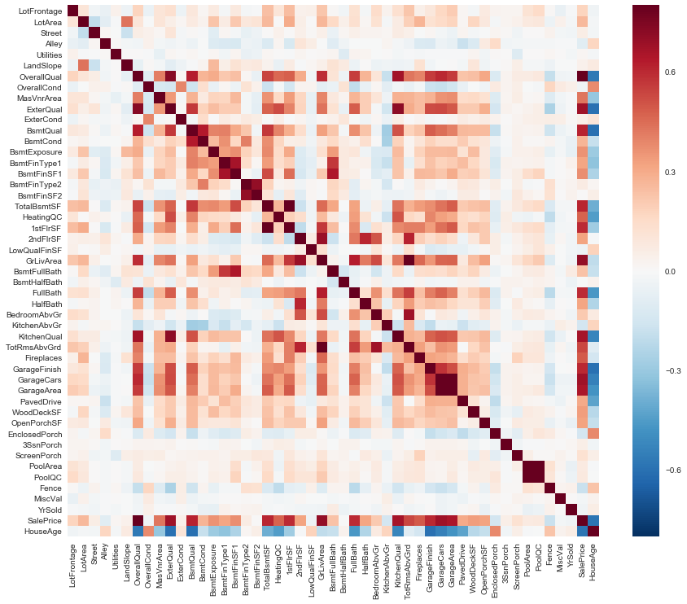

```python
# figure
corrmat = df_train.corr()
f, ax = plt.subplots(figsize=(15, 12))
sns.heatmap(corrmat, vmax=.8, square=True);

# see highest correlated ranking
corrmat.sort_values(["SalePrice"], ascending = False, inplace = True)
print(corrmat.SalePrice)
```

**From the above correlation map and rank, we could find most correlated numerical features, we could focus on, for example, set the thresholds of corr > 0.3 and corr < -0.3. And then, we could look at the categorical features.**

**By setting thresholds of 0.3 and -0.3, we found the most important features: OverallQual, GrLivArea, GarageCars, ExterQual, KitchenQual, GarageArea, BsmtQual, TotalBsmtSF, GarageFinish, 1stFlrSF, FullBath, TotRmsAbvGrd, Fireplaces, HeatingQC, MasVnrArea, BsmtFinSF1, BsmtExposure, WoodDeckSF, OpenPorchSF, 2ndFlrSF, BsmtFinType1, HalfBath, PavedDrive, and one minus correlated variable of HouseAge.**

### Further Tailor Features and Process Data (detect and process outliers etc.)

**After selecting these important features, we should further research if some features could be simplified, maybe they contain same information (so may cause multicollinearity, but multicollinearity doesn't affect final predictions precision, it just affects coefficient and p values, so I just ignored the multicollinearity problem at here), maybe we could contruct more features to do better prediction.**

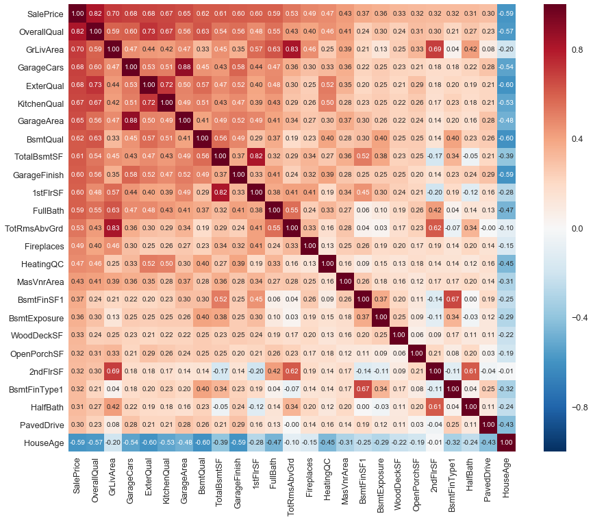

```python
# selecting those important features
import_num_features = corrmat.SalePrice[[corrmat.SalePrice.iloc[i]>0.3 or corrmat.SalePrice.iloc[i]<-0.3 \
                                         for i in range(len(corrmat.SalePrice))]].index

# show the heatmap of correlation of those important features
cm2 = df_train[import_num_features].corr()
sns.set(font_scale=1.25)
f, ax = plt.subplots(figsize=(15, 12))
hm = sns.heatmap(cm2, cbar=True, annot=True, square=True, fmt='.2f', annot_kws={'size': 10}, \
                 yticklabels=import_num_features.values, xticklabels=import_num_features.values)
plt.show()
```

**From this heatmap, we could detect highly correlated important numerical features pairs. First, we should set a threshold, for example, 0.6**

```python
# find highly correlated (>0.6 or <-0.6) pairs
pairs_ls = []
for i in range(len(cm2.columns)):
    for j in range(i):
        if (cm2.iloc[j,i] > 0.6 or cm2.iloc[j,i] < -0.6):
            pairs_ls.append(cm2.index[j] + "-" + cm2.columns[i])
pairs_ls
```

```
['SalePrice-OverallQual',
 'SalePrice-GrLivArea',
 'SalePrice-GarageCars',
 'OverallQual-GarageCars',
 'SalePrice-ExterQual',
 'OverallQual-ExterQual',
 'SalePrice-KitchenQual',
 'OverallQual-KitchenQual',
 'ExterQual-KitchenQual',
 'SalePrice-GarageArea',
 'GarageCars-GarageArea',
 'SalePrice-BsmtQual',
 'OverallQual-BsmtQual',
 'SalePrice-TotalBsmtSF',
 'SalePrice-GarageFinish',
 'TotalBsmtSF-1stFlrSF',
 'GrLivArea-FullBath',
 'GrLivArea-TotRmsAbvGrd',
 'GrLivArea-2ndFlrSF',
 'TotRmsAbvGrd-2ndFlrSF',
 'BsmtFinSF1-BsmtFinType1',
 '2ndFlrSF-HalfBath',
 'BsmtQual-HouseAge']
```

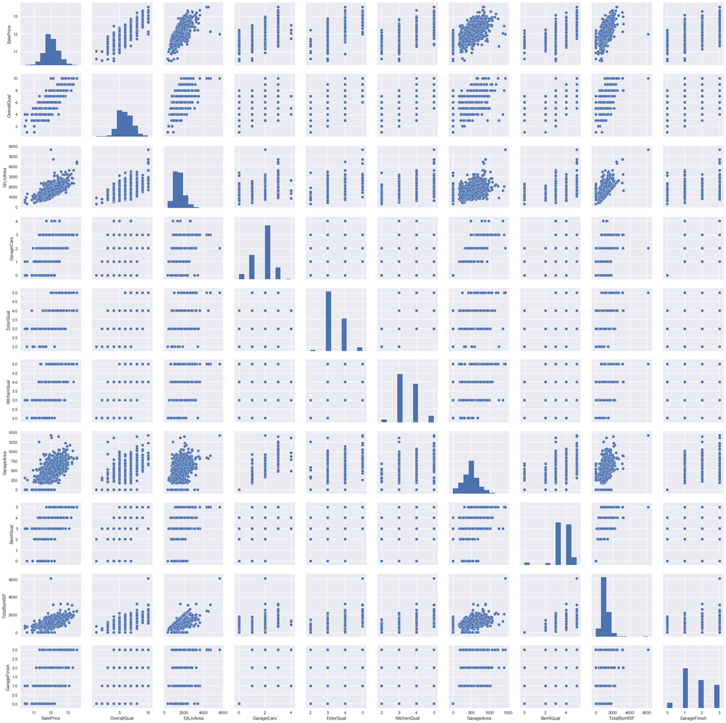

```python
# visualize a general relationship on top 10 features
sns.set()
cols = import_num_features[:10].tolist()
sns.pairplot(df_train[cols], size = 2.5)
plt.show();
```

**We could see the first row of this figure, seems the log(SalePrice) has linear realationship with all other 9 features. Also, in the third figure of the first row, we could see there seems exist outliers, see the big picture below:**

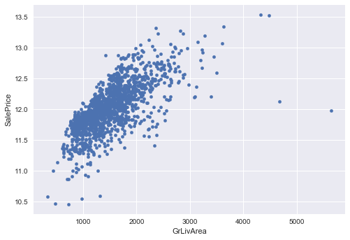

```python
data = pd.concat([df_train['SalePrice'], df_train['GrLivArea']], axis=1)
data.plot.scatter(x='GrLivArea', y='SalePrice');
```

**Clearly, the two points on the right are outliers, moreover, the author of the dataset recommends removing 'any houses with more than 4000 square feet from the dataset.**

```python
df_train = df_train[df_train.GrLivArea < 4000]
```

### This is an uncompleted project, I am still doing on this. The following steps will refer to comparing different regression models, like linear regression, ridge regression, LASSO etc. and how to improve the result, using cross validation and improve the features (for example, do some transformations or add more features). But due to the time limit, on 2019.1.27, I just stop here. Following new version of my project will be updated on my homepage [Danxuan Han's Homepage](https://danxuanhan.github.io/). Thanks!!